# 第八章 拉普拉斯变换

马越

北京理工大学机械与车辆学院  
Email: yuema@bit.edu.cn

## 目录

- **1. 引言**
- 2. 拉普拉斯变换及其收敛域
- 3. 拉普拉斯逆变换
- 4. 拉普拉斯变换的性质
- 5. 常用拉普拉斯变换对
- 6. 由零极点图对傅里叶变换几何求值
- 7. 用拉普拉斯变换分析和表征线性时不变系统
- 8. 单边拉普拉斯变换

# 引言

## 从傅里叶变换到拉普拉斯变换

1. 变换的本质与起源傅里叶分析的局限：
- 傅里叶变换将信号表示为复指数信号 $e^{st}$ 的线性组合，但其变量 $s$ 被限制在 $s = j\omega$（即复平面的虚轴）上。
- 从推广到演变：利用 LTI（线性时不变）系统特征函数的性质，将 $s$ 的取值范围从纯虚数推广到任意复数，从而推导出：
- - 拉普拉斯变换（连续时间信号的推广）
  - $z$ 变换（离散时间信号的推广）
1. 主要优势与功能分析范围更广：
   - 能够处理傅里叶变换无法覆盖的信号，尤其是对于不稳定系统的分析至关重要。
- - 系统分析工具：结合了傅里叶分析的代数性质，成为研究系统稳定性和反馈系统的核心数学支柱。

## 目录

- 1. 引言
- **2. 拉普拉斯变换及其收敛域**
- 3. 拉普拉斯逆变换
- 4. 拉普拉斯变换的性质
- 5. 常用拉普拉斯变换对
- 6. 由零极点图对傅里叶变换几何求值
- 7. 用拉普拉斯变换分析和表征线性时不变系统
- 8. 单边拉普拉斯变换

## 拉普拉斯变换及其收敛域

回忆连续时间 LTI 系统对输入 $x(t)=e^{s t}$ 的响应为

$$y(t)=(x * h)(t)=H(s) e^{s t}$$

其中 $h$ 是系统的冲激响应，且

$$H(s)=\int_{-\infty}^{\infty} h(t) e^{-s t} \, dt$$

系统函数 $H(s)$ 称为 $h$ 的拉普拉斯变换。

一般地，连续时间信号 $x(t)$ 的拉普拉斯变换为

$$X(s)=\int_{-\infty}^{\infty} x(t) e^{-s t} \, dt=\lim _{\substack{T_{1} \rightarrow \infty \\ T_{2} \rightarrow \infty}} \int_{-T_{1}}^{T_{2}} x(t) e^{-s t} \, dt$$

也可记作

$$X=\mathcal{L}\{x\}, \quad \text { 或 } \quad x(t) \stackrel{\mathcal{L}}{\longleftrightarrow} X(s)$$
复变量$s$一般可写成$s=\sigma+j\omega$

## 拉普拉斯变换及其收敛域

定义拉普拉斯变换的积分

$$X(s)=\int_{-\infty}^{\infty} x(t) e^{-s t} \, dt=\lim _{\substack{T_{1} \rightarrow \infty \\ T_{2} \rightarrow \infty}} \int_{-T_{1}}^{T_{2}} x(t) e^{-s t} \, dt$$

**收敛的 $s$ 的集合称为其收敛域（Region of Convergence, ROC）**。

### 与连续时间傅里叶变换的关系

对于 $s=\sigma+j \omega$，

$$X(\sigma+j \omega)=\int_{-\infty}^{\infty}\left\{x(t) e^{-\sigma t}\right\} e^{-j \omega t} \, dt=\mathcal{F}\left\{x(t) e^{-\sigma t}\right\}$$

若收敛域包含虚轴，令 $\sigma=0$ 可得

$$\left.X(s)\right|_{s=j \omega}=X(j \omega)=\mathcal{F}\{x\}(j \omega)$$

## 拉普拉斯变换的收敛性

根据前一页的定义，假设 $x(t)$ 在任意有限区间 $[T_1,T_2]$ 上可积。拉普拉斯变换

$$X(s)=\int_{-\infty}^{\infty} x(t) e^{-s t} \, dt=\lim _{\substack{T_{1} \rightarrow \infty \\ T_{2} \rightarrow \infty}} \int_{-T_{1}}^{T_{2}} x(t) e^{-s t} \, dt$$

的收敛性等价于以下两个积分的收敛：

$$\begin{align*}
& \int_{0}^{\infty} x(t) e^{-s t} \, dt=\lim _{T_{2} \rightarrow \infty} \int_{0}^{T_{2}} x(t) e^{-s t} \, dt \tag{$\star$}\\
& \int_{-\infty}^{0} x(t) e^{-s t} \, dt=\lim _{T_{1} \rightarrow \infty} \int_{-T_{1}}^{0} x(t) e^{-s t} \, dt
\end{align*}$$

拉普拉斯变换的收敛域是上述两个单边积分收敛域的交集。

**注**：积分 $(\star)$ 是 $x(t)$ 的单边拉普拉斯变换。

## 单边拉普拉斯变换的收敛性

**定理** 若积分 $(\star)$ 在 $s=s_{0}=\sigma_{0}+j \omega_{0}$ 处收敛，则对任意满足 $\operatorname{Re} s>\sigma_{0}$ 的 $s=\sigma+j \omega$ 也收敛。

**证明** 令

$$y(t)=\int_{0}^{t} x(\tau) e^{-s_{0} \tau} \, d \tau$$

由假设，$\lim _{t \rightarrow \infty} y(t)$ 存在，故 $M \triangleq \sup _{t \geq 0}|y(t)|<\infty$。

分部积分得

$$\begin{aligned}
\int_{0}^{T} x(t) e^{-s t} \, dt & =\int_{0}^{T} y'(t) e^{-\left(s-s_{0}\right) t} \, dt \\
& =e^{-\left(s-s_{0}\right) T} y(T)+\left(s-s_{0}\right) \int_{0}^{T} y(t) e^{-\left(s-s_{0}\right) t} \, dt
\end{aligned}$$

当 $T \rightarrow \infty$ 时，$e^{-\left(s-s_{0}\right) T} y(T) \rightarrow 0$。

## 单边拉普拉斯变换的收敛性

**定理**（续）若积分 $(\star)$ 在 $s=s_{0}$ 处收敛，则对任意 $\operatorname{Re} s>\sigma_{0}$ 的 $s$ 也收敛。

令 $s=\sigma+j \omega$，

$$\begin{aligned}
\int_{0}^{T}\left|y(t) e^{-\left(s-s_{0}\right) t}\right| \, dt & =\int_{0}^{T}|y(t)| e^{-\left(\sigma-\sigma_{0}\right) t} \, dt \\
& \leq \int_{0}^{T} M e^{-\left(\sigma-\sigma_{0}\right) t} \, dt \leq \frac{M}{\sigma-\sigma_{0}}
\end{aligned}$$

因此积分 $\int_{0}^{\infty} y(t) e^{-\left(s-s_{0}\right) t} \, dt$ 绝对收敛，从而 $(\star)$ 收敛，且

$$\int_{0}^{\infty} x(t) e^{-s t} \, dt=\left(s-s_{0}\right) \int_{0}^{\infty} y(t) e^{-\left(s-s_{0}\right) t} \, dt$$

## 单边拉普拉斯变换的收敛域

积分 $(\star)$ 的收敛有三种可能：

1. 对所有 $s \in \mathbb{C}$ 都收敛；
2. 对所有 $s \in \mathbb{C}$ 都发散；
3. 对 $\operatorname{Re} s>\sigma_{c}$（$\sigma_{c} \in \mathbb{R}$）收敛，对 $\operatorname{Re} s<\sigma_{c}$ 发散。

在情形 (c) 中，$\sigma_{c}$ 称为收敛横坐标，$\operatorname{Re} s=\sigma_{c}$ 称为收敛轴。

单边拉普拉斯变换的收敛域始终是右半平面：

$$\operatorname{ROC}=\left\{s \in \mathbb{C}: \operatorname{Re} s>\sigma_{c}\right\}$$

情形 (a) 时记 $\sigma_{c}=-\infty$，情形 (b) 时记 $\sigma_{c}=+\infty$。

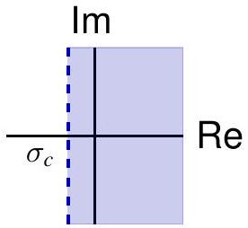

例如： $\int_{0}^{\infty} e^{t^{2}} e^{-s t} \, dt$ 对所有 $s \in \mathbb{C}$ 发散，即 $\sigma_{c}=+\infty$

例如： $\int_{0}^{\infty} e^{-t^{2}} e^{-s t} \, dt$ 对所有 $s \in \mathbb{C}$ 收敛，即 $\sigma_{c}=-\infty$

例如： $\int_{0}^{\infty} e^{-s t} \, dt$ 的 $\sigma_{c}=0$

## 单边拉普拉斯变换的绝对收敛

**定理：** 若积分 $(\star)$ 在 $s = s_0 = \sigma_0 + j\omega_0$ 处绝对收敛，则对于所有满足 $\sigma \ge \sigma_0$ 的 $s = \sigma + j\omega$，该积分均绝对收敛且一致收敛。

**证明：**

$$\int_0^{\infty} |x(t)e^{-st}|dt = \int_0^{\infty} |x(t)|e^{-\sigma t}dt \le \int_0^{\infty} |x(t)|e^{-\sigma_0 t}dt < \infty$$

### 绝对收敛域 (ROAC)

与普通收敛的情况类似，**绝对收敛域 (Region of Absolute Convergence, ROAC)** 始终是一个右半平面：

$$\text{ROAC} = \{s \in \mathbb{C} : \text{Re } s > \sigma_a\}$$

其中：

- **$\sigma_a \in \bar{\mathbb{R}}$** 称为**绝对收敛坐标**。
- 直线 **$\text{Re } s = \sigma_a$** 称为**绝对收敛轴**。

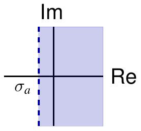

## 单边拉普拉斯变换的绝对收敛域

**收敛轴** 与 **绝对收敛轴** **并不一定重合**！

**示例：** 令 $k > 0$。为了观察到 $\sigma_a = k$，考虑以下积分：
$$\int_0^\infty e^{kt} \sin(e^{kt}) e^{-st} dt$$

当 $\text{Re } s > k$ 时，该积分绝对收敛。因为对于 $s = \sigma + j\omega$：
$$\left| e^{kt} \sin(e^{kt}) e^{-st} \right| \le e^{-(\sigma-k)t} \in L_1[0, \infty)$$

当 $s = k$ 时，积分**并非绝对收敛**，因为：$\int_0^\infty |\sin(e^{kt})| dt = \frac{1}{k} \int_1^\infty \frac{|\sin u|}{u} du = \infty$

设 $s = \sigma \in \mathbb{R}$，则有：$\int_0^\infty e^{kt} \sin(e^{kt}) e^{-\sigma t} dt = \frac{1}{k} \int_1^\infty \frac{\sin u}{u^{\sigma/k}} du$

根据 **Dirichlet 判别法**，可以得出其收敛轴为： $\sigma_c = 0$

### 结论

- **绝对收敛轴**：$\sigma_a = k$
- **收敛轴**：$\sigma_c = 0$

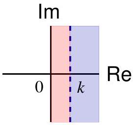

**注意：** 尽管在大多数情况下 $\text{ROC} = \text{ROAC}$，但在后续讨论中，我们将统一使用 **ROC** 这一术语。

## 双边拉普拉斯变换的收敛域

积分
$$\int_{0}^{\infty} x(t) e^{-s t} \, dt$$
的收敛域是右半平面 $\operatorname{Re} s>\sigma_{1}$。

积分
$$\int_{-\infty}^{0} x(t) e^{-s t} \, dt = \int_{0}^{\infty} x(-t) e^{-(-s) t} \, dt$$
的收敛域是左半平面
$$\operatorname{Re} s<\sigma_{2}$$

因此双边拉普拉斯变换

$$X(s)=\int_{-\infty}^{\infty} x(t) e^{-s t} \, dt$$

的收敛域是一个带状区域 $\sigma_{1} < \operatorname{Re} s < \sigma_{2}$，当且仅当 $\sigma_{1} < \sigma_{2}$ 时非空。

## 有理拉普拉斯变换

有理变换 $X(s)$ 具有以下形式

$$X(s)=\frac{N(s)}{D(s)}$$

其中 $N(s)$ 和 $D(s)$ 是互质的多项式（即没有次数 $\geq 1$ 的公因子）。

由代数基本定理，

$$X(s)=A \frac{\prod_{k=1}^{n}\left(s-z_{k}\right)}{\prod_{k=1}^{m}\left(s-p_{k}\right)}$$

约定 $\prod_{k=1}^{0} \cdot =1$。

- $z_{1}, \ldots, z_{n}$ 是 $X(s)$ 的有限零点；
- $p_{1}, \ldots, p_{m}$ 是 $X(s)$ 的有限极点；
- 若 $n>m$，则 $X(s)$ 在 $\infty$ 处有 $n-m$ 阶极点；
- 若 $n<m$，则 $X(s)$ 在 $\infty$ 处有 $m-n$ 阶零点。

## 拉普拉斯变换及其收敛域

收敛域 (ROC) 的基本性质

在分析有理拉普拉斯变换时，收敛域具有以下核心几何特性：

**性质 1**

$X(s)$ 的收敛域在 $s$ 平面内由**平行于 $j\omega$ 轴的带状区域**所组成。

**性质 2**

对于有理拉普拉斯变换来说，**收敛域内不包括任何极点**。

- **关于性质 1**：由于收敛性仅取决于信号的指数衰减/增长速率（即 $s = \sigma + j\omega$ 中的实部 $\sigma$），而与频率 $\omega$ 无关，因此 ROC 表现为垂直的带状、左半平面或右半平面。
- **关于性质 2**：极点是使 $X(s)$ 趋于无穷大的点，代表了积分发散的临界位置。因此，ROC 的边界必然由极点确定，但其内部绝不会包含极点。

## 拉普拉斯变换及其收敛域

收敛域 (ROC) 的性质 3

对于时域表现特殊的信号，其收敛域具有如下结论：

**性质 3**

如果 $x(t)$ 是**有限持续期**的，并且是**绝对可积**的，那么其收敛域就是**整个 $s$ 平面**。

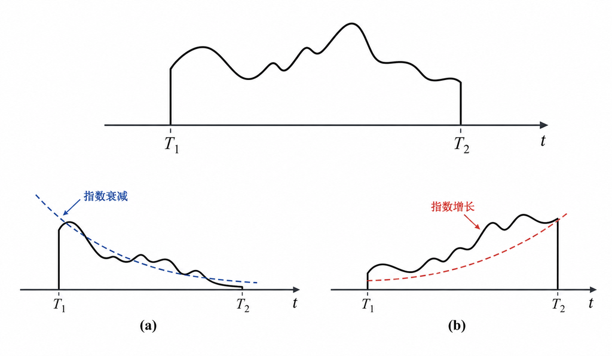

- **有限持续期信号定义**：指信号只在有限的时间区间 $[T_1, T_2]$ 内有值，而在该区间外恒为零。
- **物理直观理解**：
  - 因为信号在时间上是有限的，它不会像 $e^{at}$ 那样在 $t \to \infty$ 时无限增长。
  - 在计算积分 $\int_{t_1}^{t_2} x(t)e^{-st}dt$ 时，由于积分区间是有限的，只要 $x(t)$ 本身不发散，无论 $s$ 取什么复数值，乘上 $e^{-st}$ 后的积分结果始终是一个有限值。

## 拉普拉斯变换及其收敛域

收敛域 (ROC) 的性质 4

对于工程中最常见的信号类型，其收敛域具有如下关键特性：

**性质 4**

如果 $x(t)$ 是**右边信号**，并且 $\text{Re}\{s\} = \sigma_0$ 这条线位于收敛域内，那么 $\text{Re}\{s\} > \sigma_0$ 的全部 $s$ 值都一定在收敛域内。

- **右边信号 (Right-sided Signal)**：指信号在某个有限时间 $T_1$ 之前恒为零（即当 $t < T_1$ 时，$x(t) = 0$）。常见的因果信号（从 $t=0$ 开始）就是典型的右边信号。
- **几何表现**：性质 4 表明右边信号的 ROC 总是表现为 $s$ 平面上的一条垂直线及其右侧的全部区域。
- **与极点的关系**：结合性质 2，我们可以推论出：右边信号的 ROC 必然是位于**最右侧极点**右边的右半平面。

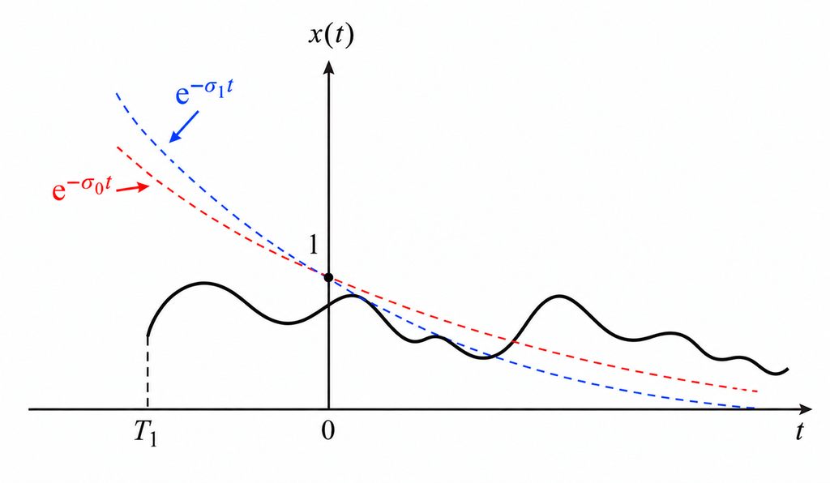

## 拉普拉斯变换及其收敛域

与右边信号相对，左边信号的收敛域具有如下特性：

**性质 5**

如果 $x(t)$ 是**左边信号**，并且 $\text{Re}\{s\} = \sigma_0$ 这条线位于收敛域内，那么 $\text{Re}\{s\} < \sigma_0$ 的全部 $s$ 值也一定在收敛域内。

- **左边信号 (Left-sided Signal)**：指信号在某个有限时间 $T_2$ 之后恒为零（即当 $t > T_2$ 时，$x(t) = 0$）。
- **几何形状**：左边信号的 ROC 表现为 $s$ 平面上某条垂直线及其**左侧**的全部区域。
- **物理意义**：
  - 对于左边信号，为了保证积分 $\int_{-\infty}^{T_2} x(t)e^{-st}dt$ 收敛，需要 $e^{-st}$ 在 $t \to -\infty$ 时衰减得足够快。
  - 这意味着 $s$ 的实部必须足够小（即足够负），从而抵消信号在负无穷方向可能的增长。

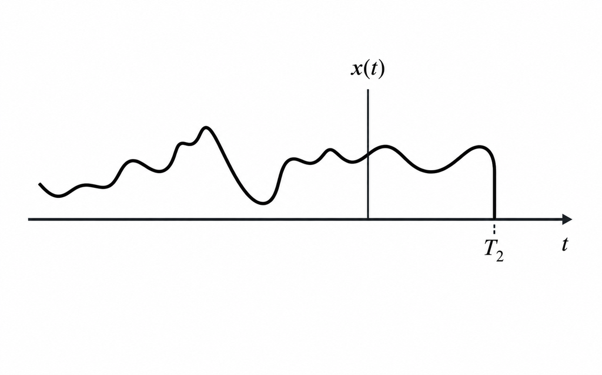

### 总结与对比

| 信号类型 | 时域特征 | ROC 形状 | 边界判定 |
| --- | --- | --- | --- |
| **右边信号** | $t > T_1$ 有值 | 右半平面 | 最右极点之右 |
| **左边信号** | $t < T_2$ 有值 | 左半平面 | 最左极点之左 |

## 拉普拉斯变换及其收敛域

对于向时间两端无限延伸的信号，其收敛域具有如下特性：

**性质 6**

如果 $x(t)$ 是**双边信号**，并且 $\text{Re}\{s\} = \sigma_0$ 这条线位于收敛域内，那么收敛域就一定由 $s$ 平面的**一条带状区域**组成，直线 $\text{Re}\{s\} = \sigma_0$ 位于带中。

- **双边信号 (Two-sided Signal)**：指在 $t \to \infty$ 和 $t \to -\infty$ 时均有值的信号。
- **形成原理**：
  - 双边信号可以拆分为一个**右边信号**和一个**左边信号**之和。
  - 总的收敛域是这两部分收敛域的**交集**。
  - 右边部分贡献了一个向右延伸的半平面，左边部分贡献了一个向左延伸的半平面，两者相交即形成“带状”区域。
- **与极点的关系**：双边信号的 ROC 位于其两组极点之间，且内部不包含任何极点。

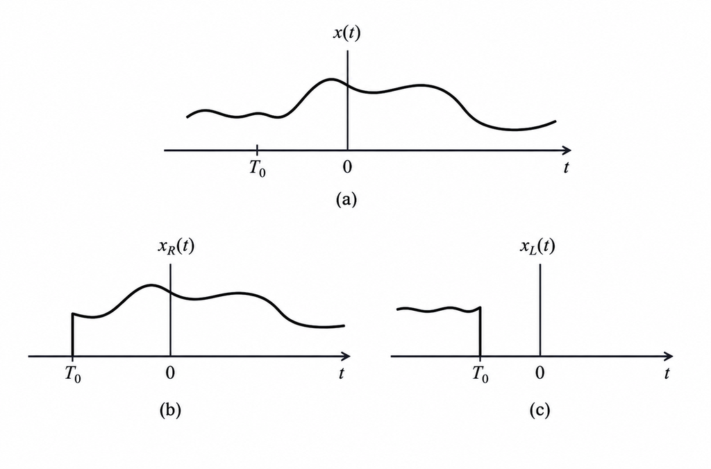

### 常见信号 ROC 总结对照

| 信号类型 | 时域范围 | ROC 几何特征 |
| --- | --- | --- |
| **有限持续期** | $T_1 < t < T_2$ | 整个 $s$ 平面 |
| **右边信号** | $t > T_1$ | 右半平面 |
| **左边信号** | $t < T_2$ | 左半平面 |
| **双边信号** | $-\infty < t < \infty$ | 带状区域 |

## 例

对于 $x(t)=e^{-a t} u(t)$，

$$X(s)=\int_{-\infty}^{\infty} e^{-a t} u(t) e^{-s t} \, dt=\int_{0}^{\infty} e^{-a t} e^{-s t} \, dt=\lim _{T \rightarrow \infty} \frac{1-e^{-(s+a) T}}{s+a}=\frac{1}{s+a},$$

收敛域为 $\operatorname{Re} s>-\operatorname{Re} a$。

若 $\operatorname{Re} a>0$，收敛域包含虚轴，

$$\mathcal{F}\{x\}(j \omega)=\left.X(s)\right|_{s=j \omega}=\frac{1}{j \omega+a}$$

若 $\operatorname{Re} a<0$，连续时间傅里叶变换不存在。

若 $\operatorname{Re} a=0$，连续时间傅里叶变换仅以分布形式存在，

$$a=j \omega_{0} \Longrightarrow \mathcal{F}\{x\}\left(e^{j \omega}\right)=\frac{1}{j\left(\omega+\omega_{0}\right)}+\pi \delta\left(\omega+\omega_{0}\right) \neq\left. X(s)\right|_{s=j \omega}$$

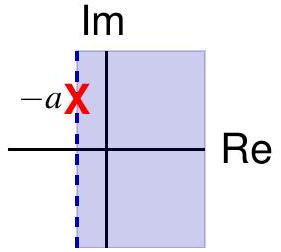

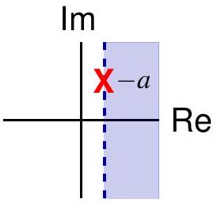

## 例

对于 $x(t)=-e^{-a t} u(-t)$，

$$X(s)=-\int_{-\infty}^{0} e^{-a t} e^{-s t} \, dt=\lim _{T \rightarrow \infty} \frac{1-e^{(s+a) T}}{s+a}=\frac{1}{s+a},$$

收敛域为 $\operatorname{Re} s<-\operatorname{Re} a$。

若 $\operatorname{Re} a<0$，收敛域包含虚轴，

$$\mathcal{F}\{x\}(j \omega)=\left.X(s)\right|_{s=j \omega}=\frac{1}{j \omega+a}$$

若 $\operatorname{Re} a>0$，连续时间傅里叶变换不存在。

若 $\operatorname{Re} a=0$，连续时间傅里叶变换仅以分布形式存在，

$$a=j \omega_{0} \Longrightarrow \mathcal{F}\{x\}\left(e^{j \omega}\right)=\frac{1}{j\left(\omega+\omega_{0}\right)}+\pi \delta\left(\omega+\omega_{0}\right) \neq\left. X(s)\right|_{s=j \omega}$$

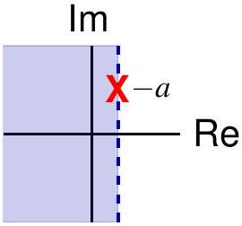

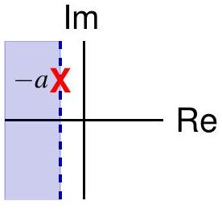

## 收敛域的重要性

$x_{1}(t)=e^{-a t} u(t) \stackrel{\mathcal{L}}{\longleftrightarrow} X_{1}(s)=\frac{1}{s+a}$，  
ROC $\operatorname{Re} s>-\operatorname{Re} a$

$x_{2}(t)=-e^{-a t} u(-t) \stackrel{\mathcal{L}}{\longleftrightarrow} X_{2}(s)=\frac{1}{s+a}$，  
ROC $\operatorname{Re} s<-\operatorname{Re} a$

**不同的信号可以有相同的 $X(s)$ 但不同的收敛域。**

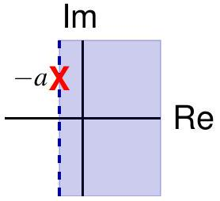

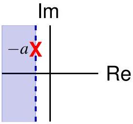

**拉普拉斯变换必须始终指明收敛域！**

## 例

对于 $x(t)=3 e^{-2 t} u(t)-2 e^{-t} u(t)$，

$$\begin{aligned}
X(s) & =\int_{0}^{\infty}\left[3 e^{-2 t} u(t)-2 e^{-t} u(t)\right] e^{-s t} \, dt \\
& =\frac{3}{s+2}-\frac{2}{s+1} \\
& =\frac{s-1}{(s+2)(s+1)}
\end{aligned}$$

收敛域 $\operatorname{Re} s>-1$。

有两个简单极点：$s=-2$ 和 $s=-1$；  
一个简单零点：$s=1$；  
在 $\infty$ 处还有一个简单零点。

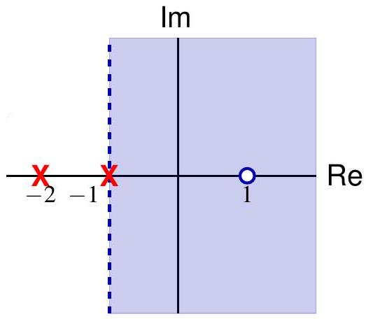

## 例

对于 $x(t)=e^{-2 t} u(t)+e^{-t} \cos (3 t) u(t)=e^{-2 t}+\frac{1}{2} e^{-(1-3 j) t}+\frac{1}{2} e^{-(1+3 j) t}$，

$$\begin{aligned}
X(s) & =\frac{1}{s+2}+\frac{1}{2} \frac{1}{s+(1-3 j)}+\frac{1}{2} \frac{1}{s+(1+3 j)} \\
& =\frac{2 s^{2}+5 s+12}{\left(s^{2}+2 s+10\right)(s+2)} \\
& =2 \frac{\left(s+\frac{5+j \sqrt{71}}{4}\right)\left(s+\frac{5-j \sqrt{71}}{4}\right)}{(s+2)(s+1-3 j)(s+1+3 j)}
\end{aligned}$$

收敛域 $\operatorname{Re} s>-1$。

简单极点位于 $s=-2$ 和 $s=-1 \pm 3 j$；  
简单零点位于 $s=\frac{-5 \pm j \sqrt{71}}{4}$；  
在 $\infty$ 处还有一个简单零点。

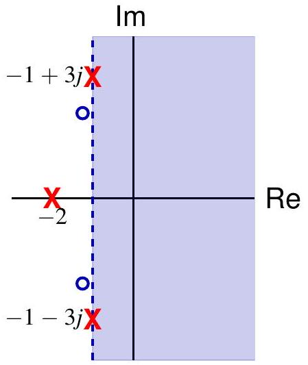

## 例

考虑 $x(t)=e^{-b|t|}=e^{-b t} u(t)+e^{b t} u(-t)$。已知

$$\begin{aligned}
& e^{-b t} u(t) \stackrel{\mathcal{L}}{\longleftrightarrow} \frac{1}{s+b}, \quad \operatorname{Re} s>-b \\
& e^{b t} u(-t) \stackrel{\mathcal{L}}{\longleftrightarrow} \frac{-1}{s-b}, \quad \operatorname{Re} s<b
\end{aligned}$$

因此

$$x(t)=e^{-b|t|} \stackrel{\mathcal{L}}{\longleftrightarrow} \frac{1}{s+b}-\frac{1}{s-b}=\frac{-2b}{s^{2}-b^{2}}, \quad -b < \operatorname{Re} s < b$$

收敛域非空的条件是 $b>0$。

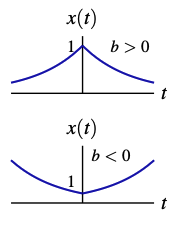

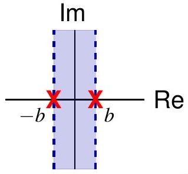

## 目录

- 1. 引言
- 2. 拉普拉斯变换及其收敛域
- **3. 拉普拉斯逆变换**
- 4. 拉普拉斯变换的性质
- 5. 常用拉普拉斯变换对
- 6. 由零极点图对傅里叶变换几何求值
- 7. 用拉普拉斯变换分析和表征线性时不变系统
- 8. 单边拉普拉斯变换

# 拉普拉斯逆变换

## 拉普拉斯逆变换

回忆拉普拉斯变换与连续时间傅里叶变换的关系：

$$X(\sigma + j\omega) = \int_{-\infty}^{\infty} \{x(t) e^{-\sigma t}\} e^{-j\omega t} \, dt = \mathcal{F}\{x(t) e^{-\sigma t}\}$$

对 $s=\sigma + j\omega \in \mathrm{ROC}$ 取傅里叶逆变换：

$$x(t) e^{-\sigma t} = \frac{1}{2\pi} \int_{-\infty}^{\infty} X(\sigma + j\omega) e^{j\omega t} \, d\omega$$

因此

$$x(t) = \frac{1}{2\pi} \int_{-\infty}^{\infty} X(\sigma + j\omega) e^{(\sigma + j\omega) t} \, d\omega$$

或

$$x(t) = \frac{1}{j 2\pi} \int_{\sigma - j\infty}^{\sigma + j\infty} X(s) e^{s t} \, ds = \lim_{A\to\infty} \frac{1}{j 2\pi} \int_{\sigma - j A}^{\sigma + j A} X(s) e^{s t} \, ds$$

## 部分分式展开求逆变换

对于有理拉普拉斯变换，可通过部分分式展开求逆变换。

一个严格真有理函数的部分分式展开形式为

$$R(s) = \sum_{i=1}^{r} \sum_{k_{i}=1}^{N_{i}} \frac{A_{i,k_{i}}}{(s + a_{i})^{k_{i}}}$$

同时

$$\begin{aligned}
\frac{t^{n-1}}{(n-1)!} e^{-a t} u(t) &\stackrel{\mathcal{L}}{\longleftrightarrow} \frac{1}{(s+a)^{n}}, && \operatorname{Re} s > -a \\
-\frac{t^{n-1}}{(n-1)!} e^{-a t} u(-t) &\stackrel{\mathcal{L}}{\longleftrightarrow} \frac{1}{(s+a)^{n}}, && \operatorname{Re} s < -a
\end{aligned}$$

由线性性质，$\mathcal{L}^{-1}\{R\}$ 是上述形式各项的线性组合，符号根据 ROC 选取。

## 例

考虑有理拉普拉斯变换 $X(s)=\frac{1}{(s+1)(s+2)^{2}}$

$$X(s) = \frac{1}{s+1} + \frac{-1}{s+2} + \frac{-1}{(s+2)^{2}}$$

极点位于 $s=-1$ 和 $s=-2$。

1. 若 ROC 为 $\operatorname{Re} s > -1$

$$x(t) = e^{-t} u(t) - (1+t) e^{-2t} u(t)$$

2. 若 ROC 为 $\operatorname{Re} s < -2$

$$x(t) = -e^{-t} u(-t) + (1+t) e^{-2t} u(-t)$$

3. 若 ROC 为 $-2 < \operatorname{Re} s < -1$

$$x(t) = -e^{-t} u(-t) - (1+t) e^{-2t} u(t)$$

## 围线积分求逆变换

假设 $X(s)$ 有有限个有限孤立奇点 $s_{1},\dots,s_{n}$，且 ROC 为 $-\infty \leq \sigma_{1} < \operatorname{Re} s < \sigma_{2} \leq +\infty$。

逆变换为

$$x(t) = \lim_{r\to\infty} \frac{1}{j 2\pi} \int_{\sigma - j r}^{\sigma + j r} X(s) e^{s t} \, ds$$

其中 $\sigma_{1} < \sigma < \sigma_{2}$。

对于 $t>0$，选取一个包含所有 $\operatorname{Re} s \leq \sigma_{1}$ 的奇点 $s_{k}$ 的大半圆 $C_{r}$。

若 $X(s)$ 满足 Jordan 引理，由留数定理得

$$x(t) = \sum_{k: \operatorname{Re} s_{k} \leq \sigma_{1}} \operatorname{Res}[X(s) e^{s t}, s_{k}], \quad t>0$$

（对严格真有理函数成立）

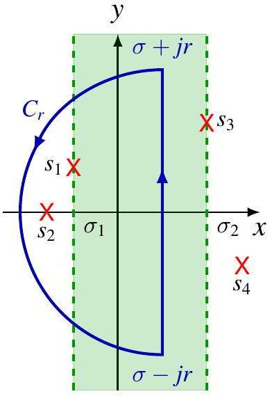

## 围线积分求逆变换

对于 $t<0$，选取包含所有 $\operatorname{Re} s \geq \sigma_{2}$ 的奇点的大半圆。

由留数定理得

$$x(t) = -\sum_{k: \operatorname{Re} s_{k} \geq \sigma_{2}} \operatorname{Res}[X(s) e^{s t}, s_{k}], \quad t<0$$
**注意**：负号源于围线的负方向。

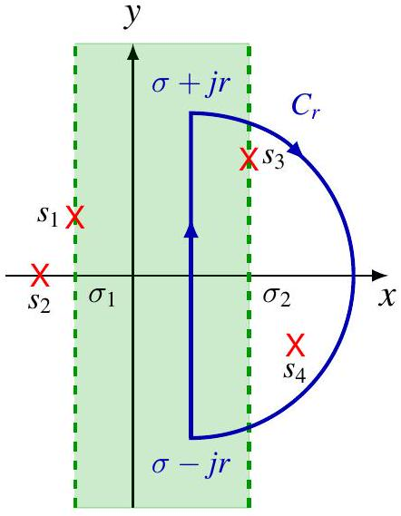

## 例

考虑 $X(s)=\frac{1}{(s+1)(s+2)^{2}}$

$$\begin{gathered}
\operatorname{Res}[X(s) e^{s t}, -1] = \left.\frac{e^{s t}}{(s+2)^{2}}\right|_{s=-1} = e^{-t} \\
\operatorname{Res}[X(s) e^{s t}, -2] = \left[\frac{d}{ds} \frac{e^{s t}}{s+1}\right]_{s=-2} = -(1+t) e^{-2t}
\end{gathered}$$

1. 若 ROC 为 $\operatorname{Re} s > -1$，则 $\sigma_{1}=-1$，$\sigma_{2}=+\infty$。

$t>0$ 时：

$$x(t) = e^{-t} - (1+t) e^{-2t}$$

$t<0$ 时：

$$x(t) = 0$$

## 例（续）

考虑 $X(s)=\frac{1}{(s+1)(s+2)^{2}}$

$$\begin{gathered}
\operatorname{Res}[X(s) e^{s t}, -1] = \left.\frac{e^{s t}}{(s+2)^{2}}\right|_{s=-1} = e^{-t} \\
\operatorname{Res}[X(s) e^{s t}, -2] = \left[\frac{d}{ds} \frac{e^{s t}}{s+1}\right]_{s=-2} = -(1+t) e^{-2t}
\end{gathered}$$

2. 若 ROC 为 $\operatorname{Re} s < -2$，则 $\sigma_{1}=-\infty$，$\sigma_{2}=-2$。

$t>0$ 时：$x(t)=0$

$t<0$ 时：

$$x(t) = -e^{-t} + (1+t) e^{-2t}$$

## 例（续）

考虑 $X(s)=\frac{1}{(s+1)(s+2)^{2}}$

$$\begin{gathered}
\operatorname{Res}[X(s) e^{s t}, -1] = \left.\frac{e^{s t}}{(s+2)^{2}}\right|_{s=-1} = e^{-t} \\
\operatorname{Res}[X(s) e^{s t}, -2] = \left[\frac{d}{ds} \frac{e^{s t}}{s+1}\right]_{s=-2} = -(1+t) e^{-2t}
\end{gathered}$$

3. 若 ROC 为 $-2 < \operatorname{Re} s < -1$，则 $\sigma_{1}=-2$，$\sigma_{2}=-1$。

$t>0$ 时：

$$x(t) = -(1+t) e^{-2t}$$

$t<0$ 时：

$$x(t) = -e^{-t}$$

## 目录

- 1. 引言
- 2. 拉普拉斯变换及其收敛域
- 3. 拉普拉斯逆变换
- **4. 拉普拉斯变换的性质**
- 5. 常用拉普拉斯变换对
- 6. 由零极点图对傅里叶变换几何求值
- 7. 用拉普拉斯变换分析和表征线性时不变系统
- 8. 单边拉普拉斯变换

# 拉普拉斯变换的性质

## 线性性质

若

$$\begin{array}{ll}
x(t) \stackrel{\mathcal{L}}{\longleftrightarrow} X(s) & \text{收敛域}=R_{1} \\
y(t) \stackrel{\mathcal{L}}{\longleftrightarrow} Y(s) & \text{收敛域}=R_{2}
\end{array}$$

则

$$a x(t)+b y(t) \stackrel{\mathcal{L}}{\longleftrightarrow} a X(s)+b Y(s) \quad \text{收敛域} \supset R_{1} \cap R_{2}$$

**注**：实际收敛域可能比 $R_1 \cap R_2$ 大。

**例**  
$x(t)=\cos(\omega_0 t) u(t)$ 的拉普拉斯变换为 $\frac{s}{s^2+\omega_0^2}$，收敛域 $\operatorname{Re} s>0$；

$\sin(\omega_0 t) u(t)$ 的拉普拉斯变换为 $\frac{\omega_0}{s^2+\omega_0^2}$，收敛域 $\operatorname{Re} s>0$。

## 线性性质（例子）

$X_1(s)=\frac{1}{s+1}$，$\operatorname{Re} s>-1$；  
$X_2(s)=\frac{1}{(s+1)(s+2)}$，$\operatorname{Re} s>-1$；

$$X(s)=X_1(s)-X_2(s)=\frac{1}{s+2}, \quad \operatorname{Re} s>-2$$

由于 $s=-1$ 处的极零点抵消，收敛域扩大了。

时域中：

$x_1(t)=e^{-t} u(t)$，$x_2(t)=e^{-t} u(t)-e^{-2t} u(t)$，  
$x(t)=e^{-2t} u(t)$。

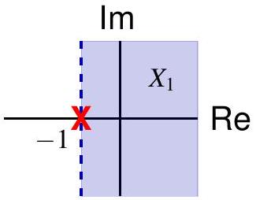

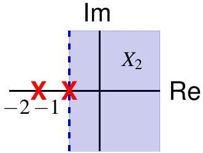

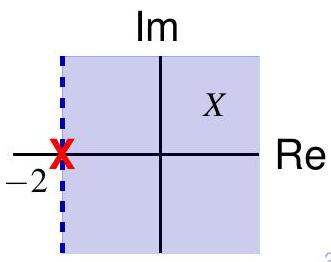

## 时移性质

若

$$x(t) \stackrel{\mathcal{L}}{\longleftrightarrow} X(s), \quad \sigma_{1}<\operatorname{Re} s<\sigma_{2}$$

则

$$x(t-t_0) \stackrel{\mathcal{L}}{\longleftrightarrow} e^{-s t_0} X(s), \quad \sigma_{1}<\operatorname{Re} s<\sigma_{2}$$

**例**

$$? \stackrel{\mathcal{L}}{\longleftrightarrow} \frac{e^{3s}}{s+2}, \quad \operatorname{Re} s>-2$$

已知 $x(t)=e^{-2t} u(t) \stackrel{\mathcal{L}}{\longleftrightarrow} \frac{1}{s+2}$，则 $x(t+3)=e^{-2(t+3)} u(t+3)$ 对应上述变换。

## $s$ 域平移性质

若

$$x(t) \stackrel{\mathcal{L}}{\longleftrightarrow} X(s), \quad \sigma_{1}<\operatorname{Re} s<\sigma_{2}$$

则

$$e^{s_0 t} x(t) \stackrel{\mathcal{L}}{\longleftrightarrow} X(s-s_0), \quad \sigma_{1}+\operatorname{Re} s_0 < \operatorname{Re} s < \sigma_{2}+\operatorname{Re} s_0$$

**例** 对于实数 $\alpha$，

$$\begin{aligned}
e^{-\alpha t} \cos(\omega_0 t) u(t) &\stackrel{\mathcal{L}}{\longleftrightarrow} \frac{s+\alpha}{(s+\alpha)^2+\omega_0^2}, && \operatorname{Re} s>-\alpha \\
e^{-\alpha t} \sin(\omega_0 t) u(t) &\stackrel{\mathcal{L}}{\longleftrightarrow} \frac{\omega_0}{(s+\alpha)^2+\omega_0^2}, && \operatorname{Re} s>-\alpha
\end{aligned}$$
*性质汇总

## 时间尺度变换

若

$$x(t) \stackrel{\mathcal{L}}{\longleftrightarrow} X(s), \quad \sigma_{1}<\operatorname{Re} s<\sigma_{2}$$

则对 $a \in \mathbb{R} \setminus \{0\}$，

$$x(a t) \stackrel{\mathcal{L}}{\longleftrightarrow} \frac{1}{|a|} X\left(\frac{s}{a}\right), \quad \sigma_{1} < \frac{1}{a} \operatorname{Re} s < \sigma_{2}$$

时间反转时：

$$x(-t) \stackrel{\mathcal{L}}{\longleftrightarrow} X(-s), \quad -\sigma_{2} < \operatorname{Re} s < -\sigma_{1}$$

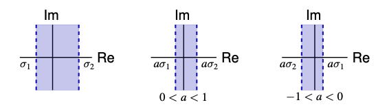

## 共轭性质

若

$$x(t) \stackrel{\mathcal{L}}{\longleftrightarrow} X(s), \quad \sigma_{1}<\operatorname{Re} s<\sigma_{2}$$

则

$$x^*(t) \stackrel{\mathcal{L}}{\longleftrightarrow} X^*(s^*), \quad \sigma_{1}<\operatorname{Re} s<\sigma_{2}$$

若 $x(t)$ 为实信号，则 $X(s)=X^*(s^*)$，零点和极点以共轭对形式出现。

**例**

$$x(t)=e^{-2t} u(t)+e^{-t} \cos(3t) u(t)$$

收敛域 $\operatorname{Re} s>-1$。

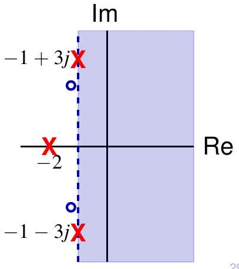

## 卷积性质

若

$$\begin{array}{ll}
x(t) \stackrel{\mathcal{L}}{\longleftrightarrow} X(s) & \text{ROAC}=R_1 \\
y(t) \stackrel{\mathcal{L}}{\longleftrightarrow} Y(s) & \text{ROAC}=R_2
\end{array}$$

则

$$(x*y)(t) \stackrel{\mathcal{L}}{\longleftrightarrow} X(s)Y(s) \quad \text{ROAC} \supset R_1 \cap R_2$$

更精确的定理：若两者在 $s_0$ 处绝对收敛，则卷积的变换在 $s_0$ 处也绝对收敛，且 $X(s_0)Y(s_0)=Z(s_0)$。

**定理：** 若 $X(s) = \int_{-\infty}^{\infty} x(t)e^{-st}dt$ 和 $Y(s) = \int_{-\infty}^{\infty} y(t)e^{-st}dt$ 在某个 $s = s_0$ 处均**绝对收敛**，则 $z = x * y$ 的拉普拉斯变换在 $s = s_0$ 处也绝对收敛，且满足：

$$X(s_0)Y(s_0) = Z(s_0) = \int_{-\infty}^{\infty} z(t)e^{-s_0t}dt$$

## 卷积性质（证明与例子）

**证明**（利用 Fubini 定理交换积分顺序）。

$$\begin{aligned}
X(s)Y(s) &= \int_{-\infty}^{\infty} x(v) \left[ \int_{-\infty}^{\infty} y(\tau)e^{-s(v+\tau)} d\tau \right] dv \\
&= \int_{-\infty}^{\infty} x(v) \left[ \int_{-\infty}^{\infty} y(t-v)e^{-st} dt \right] dv \quad (令 \, t = v + \tau) \\
&= \int_{-\infty}^{\infty} \left[ \int_{-\infty}^{\infty} x(v)y(t-v) dv \right] e^{-st} dt \quad (\text{根据 Fubini 定理})
\end{aligned}$$

由此可见，上式右端即为卷积信号 $z(t) = (x * y)(t)$ 的拉普拉斯变换 $Z(s)$。

### 补充说明

**注意：** 卷积信号 $\mathcal{L}\{x * y\}$ 的 **绝对收敛域 (ROAC)** 可能会比 $\mathcal{L}\{x\}$ 和 $\mathcal{L}\{y\}$ 的公共绝对收敛域更宽。

**例** $X_1(s)=\frac{s+1}{(s+2)^2}$（ROAC $\operatorname{Re} s>-2$）与 $X_2(s)=\frac{1}{s+1}$（ROAC $\operatorname{Re} s>-1$）相乘后得到 $\frac{1}{(s+2)^2}$，ROAC 扩大到 $\operatorname{Re} s>-2$（因 $s=-1$ 处极零点抵消）。

## 时域微分性质

若

$$x(t) \stackrel{\mathcal{L}}{\longleftrightarrow} X(s), \quad \text{收敛域}=R$$

且 $\lim_{t\to\pm\infty} x(t)e^{-s t}=0$ 对 $s\in R$ 成立，则

$$\frac{d}{dt}x(t) \stackrel{\mathcal{L}}{\longleftrightarrow} s X(s), \quad \text{收敛域} \supset R \cap R_0$$

**证明：**

利用**分部积分法**可得：

$$\int_{-\infty}^{\infty} x'(t)e^{-st} dt = \left. x(t)e^{-st} \right|_{-\infty}^{\infty} + s \int_{-\infty}^{\infty} x(t)e^{-st} dt = s \int_{-\infty}^{\infty} x(t)e^{-st} dt$$

**注意 (NB)：** 微分运算可能导致收敛域 (ROC) **扩大**或**缩小**。

## 时域微分性质（例子）

**示例：** 考虑信号 $x(t) = (1 - e^{-t})u(t)$，其拉普拉斯变换为：
$$x(t) \stackrel{\mathcal{L}}{\longleftrightarrow} \frac{1}{s(s+1)}$$
此时其 $\text{ROC} = \text{ROAC}$ 为 $\text{Re } s > 0$。

对其求导得 $x'(t) = e^{-t}u(t)$，其变换为：
$$x'(t) \stackrel{\mathcal{L}}{\longleftrightarrow} \frac{1}{s+1}$$
此时其 $\text{ROC} = \text{ROAC}$ 为 $\text{Re } s > -1$。

**结论：** 在本例中，$\mathcal{L}\{x'\}$ 的收敛域比 $\mathcal{L}\{x\}$ 的收敛域更**大**。

## 时域微分性质（例子）

考虑信号 $x(t) = e^{kt} \sin(e^{kt})$，其中 $k > 0$。

- 对于 $s = \sigma \in \mathbb{R}$，令 $u = e^{kt}$ 进行变量代换可得：
  $$\int_{-\infty}^{\infty} x(t)e^{-st} dt = \frac{1}{k} \int_{0}^{\infty} \frac{\sin u}{u^{\sigma/k}} du = \frac{1}{k} \int_{0}^{1} \frac{\sin u}{u^{\sigma/k}} du + \frac{1}{k} \int_{1}^{\infty} \frac{\sin u}{u^{\sigma/k}} du$$
  - $\int_{1}^{\infty} \frac{\sin u}{u^{\sigma/k}} du$ 的 **ROAC** 为 $\text{Re } s > k$，而 **ROC** 为 $\text{Re } s > 0$。
  - 当 $u \downarrow 0$ 时，$\frac{\sin u}{u^{\sigma/k}} \sim u^{1-\sigma/k}$，因此 $\int_{0}^{1} \frac{\sin u}{u^{\sigma/k}} du$ 的 **ROAC** 为 $\text{Re } s < 2k$。
  - **综上所述**：$\mathcal{L}\{x\}$ 的 **ROAC** 为 $k < \text{Re } s < 2k$，其 **ROC** 为 $0 < \text{Re } s < 2k$。

计算导数 $x'(t) = ke^{kt} \sin(e^{kt}) + ke^{2kt} \cos(e^{kt})$。对于 $s = \sigma \in \mathbb{R}$：

$$\int_{-\infty}^{\infty} x'(t)e^{-st} dt = \int_{0}^{\infty} \frac{\sin u + u \cos u}{u^{\sigma/k}} du$$

- $\mathcal{L}\{x'\}$ 的 **ROAC 为空集 (Empty)**。
- 其 **ROC** 为 $k < \text{Re } s < 2k$。
- **注意**：在 $0 < \text{Re } s < k$ 的范围内，条件 $\lim_{t \to \pm\infty} x(t)e^{-st} = 0$ **无法满足**。
- 这个例子有力地证明了：虽然微分性质通常成立，但必须严格检查边界项以及 ROC 的重合情况。

若信号满足当 $t \to +\infty$ 时 $x(t) = O(e^{at})$，且当 $t \to -\infty$ 时 $x(t) = O(e^{bt})$，则：

$$x(t) \stackrel{\mathcal{L}}{\longleftrightarrow} X(s), \quad \text{其 ROAC 包含 } a < \text{Re } s < b$$

并且：

$$\frac{d}{dt}x(t) \stackrel{\mathcal{L}}{\longleftrightarrow} sX(s), \quad \text{其 ROC 包含 } a < \text{Re } s < b$$

- **一般结论**：通常情况下，从 $\mathcal{L}\{x\}$ 在 $s = s_0$ 处的**绝对收敛**，我们只能推导出 $\mathcal{L}\{x'\}$ 在 $s = s_0$ 处的**普通收敛**。
- **常见信号形式**：在工程实践中，我们主要处理形式为 $\sum_{k=0}^{m} p_k(t)e^{\alpha_k t}u(\pm t + \beta_k)$ 的信号，其中 $p_k$ 是多项式。在引入奇异函数（Singularity Functions）的拉普拉斯变换后，对于此类函数有：

$$\frac{d^n}{dt^n}x(t) \stackrel{\mathcal{L}}{\longleftrightarrow} s^n X(s), \quad \text{其 ROC 包含 } a < \text{Re } s < b$$

**理解导数项对 ROC 的影响至关重要**

- **ROAC (绝对收敛域)**：通常对应于物理系统的能量有限性或稳定性边界。
- **奇异函数**：如单位脉冲 $\delta(t)$ 及其导数的引入，使得我们能够统一处理包含初始状态跳变的高阶微分方程模型。

## $s$ 域微分性质

若
$$x(t) \stackrel{\mathcal{L}}{\longleftrightarrow} X(s), \quad \sigma_1 < \text{Re } s < \sigma_2$$
则
$$-tx(t) \stackrel{\mathcal{L}}{\longleftrightarrow} \frac{d}{ds}X(s), \quad \sigma_1 < \text{Re } s < \sigma_2$$

**证明**： （利用**积分号内求导**）

$$\frac{d}{ds} \int_{-\infty}^{\infty} x(t)e^{-st} dt = \int_{-\infty}^{\infty} x(t) \frac{d}{ds} e^{-st} dt = \int_{-\infty}^{\infty} -tx(t)e^{-st} dt$$

例如，已知： $e^{-at}u(t) \stackrel{\mathcal{L}}{\longleftrightarrow} \frac{1}{s+a}, \quad \text{Re } s > -a$

利用上述性质，可推得： $t^n e^{-at}u(t) \stackrel{\mathcal{L}}{\longleftrightarrow} \left( -\frac{d}{ds} \right)^n \frac{1}{s+a} = \frac{n!}{(s+a)^{n+1}}, \quad \text{Re } s > -a$

同理：
$$-t^n e^{-at}u(-t) \stackrel{\mathcal{L}}{\longleftrightarrow} \frac{n!}{(s+a)^{n+1}}, \quad \text{Re } s < -a$$

## 拉普拉斯变换性质汇总（1/2）

| 节次 | 性质 | 信号 | 拉普拉斯变换 | 收敛域 (ROC) |
| --- | --- | --- | --- | --- |
|  |  | $x(t)$ $x_1(t)$ $x_2(t)$ | $X(s)$ $X_1(s)$ $X_2(s)$ | $R$ $R_1$ $R_2$ |
| 9.5.1 | **线性** | $ax_1(t) + bx_2(t)$ | $aX_1(s) + bX_2(s)$ | 至少 $R_1 \cap R_2$ |
| 9.5.2 | **时移** | $x(t - t_0)$ | $e^{-st_0}X(s)$ | $R$ |
| 9.5.3 | **$s$ 域平移** | $e^{s_0 t}x(t)$ | $X(s - s_0)$ | $R$ 的平移 (即若 $(s-s_0) \in R$) |
| 9.5.4 | **时域尺度变换** | $x(at)$ | $\frac{1}{\\|a\\|}X(\frac{s}{a})$ | $R/a$ (即若 $s/a \in R$) |
| 9.5.5 | **共轭** | $x^*(t)$ | $X^*(s^*)$ | $R$ |
| 9.5.6 | **卷积** | $x_1(t) * x_2(t)$ | $X_1(s)X_2(s)$ | 至少 $R_1 \cap R_2$ |
| 9.5.7 | **时域微分** | $\frac{d}{dt}x(t)$ | $sX(s)$ | 至少 $R$ |
| 9.5.8 | **$s$ 域微分** | $-tx(t)$ | $\frac{d}{ds}X(s)$ | $R$ |
| 9.5.9 | **时域积分** | $\int_{-\infty}^{t} x(\tau)d\tau$ | $\frac{1}{s}X(s)$ | 至少 $R \cap \{\text{Re}\{s\} > 0\}$ |

## 拉普拉斯变换性质汇总（2/2）

**初值定理与终值定理 (9.5.10)**：若 $t < 0$ 时 $x(t) = 0$，且在 $t = 0$ 处不包括任何冲激或高阶奇异函数，则：

### 初值定理 (Initial-Value Theorem)

$$x(0^+) = \lim_{s \to \infty} sX(s)$$

### 终值定理 (Final-Value Theorem)

$$\lim_{t \to \infty} x(t) = \lim_{s \to 0} sX(s)$$

## 奇异函数的拉普拉斯变换

我们也可以对广义函数定义拉普拉斯变换。本课程仅考虑 $\delta(t)$ 及其导数的变换。形式上：

$$\begin{aligned}
\mathcal{L}\{\delta\} &= \int_{-\infty}^{\infty} \delta(t) e^{-s t} \, dt = 1 \\
\mathcal{L}\{\delta'\} &= \int_{-\infty}^{\infty} \delta'(t) e^{-s t} \, dt = -\left.\frac{d}{dt} e^{-s t}\right|_{t=0} = s \\
\mathcal{L}\{\delta^{(k)}\} &= \int_{-\infty}^{\infty} \delta^{(k)}(t) e^{-s t} \, dt = \left.(-1)^{k} \frac{d^{k}}{dt^{k}} e^{-s t}\right|_{t=0} = s^{k}
\end{aligned}$$

这些变换对所有 $s \in \mathbb{C}$ 都有定义，我们称“ROC”为 $\mathbb{C}$（尽管不存在收敛性问题）。

## 奇异函数的拉普拉斯变换

之前讨论的拉普拉斯变换性质对这一推广仍然成立。

**例** 时域微分性质等价于包含 $\delta'$ 的卷积性质：

$$\mathcal{L}\{x'\} = \mathcal{L}\{x * \delta'\} = \mathcal{L}\{x\} \mathcal{L}\{\delta'\} = s \mathcal{L}\{x\}$$

**例**

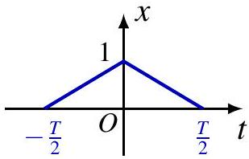

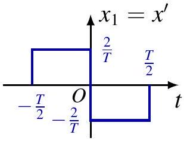

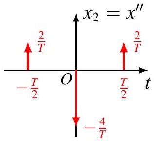

$X_{2}(s) = -\frac{4}{T} + \frac{2}{T} e^{-s \frac{T}{2}} + \frac{2}{T} e^{s \frac{T}{2}} = \frac{8}{T} \sinh^{2}\left(\frac{s T}{4}\right) \Longrightarrow X(s) = \frac{X_{2}(s)}{s^{2}}$

## 拉普拉斯逆变换（含多项式部分）

有理函数可写成一个多项式与严格真有理函数之和：

$$R(s) = \sum_{k=1}^{n} a_{k} s^{k} + R_{1}(s)$$

因此

$$\mathcal{L}^{-1}\{R\} = \sum_{k=1}^{n} a_{k} \delta^{(k)}(t) + \mathcal{L}^{-1}\{R_{1}\}$$

其中 $\mathcal{L}^{-1}\{R_{1}\}$ 可通过部分分式展开或围线积分求得。

**例** $X(s)=\frac{s(s+2)}{s+3} = s - 1 + \frac{3}{s+3}$，ROC $\operatorname{Re} s > -3$，故

$$x(t) = \delta'(t) - \delta(t) + 3 e^{-3t} u(t)$$

## 目录

- 1. 引言
- 2. 拉普拉斯变换及其收敛域
- 3. 拉普拉斯逆变换
- 4. 拉普拉斯变换的性质
- **5. 常用拉普拉斯变换对**
- 6. 由零极点图对傅里叶变换几何求值
- 7. 用拉普拉斯变换分析和表征线性时不变系统
- 8. 单边拉普拉斯变换

# 常用拉普拉斯变换对

## 常用拉普拉斯变换对（1/2）

| 变换对 | 信号 $x(t)$ | 变换 $X(s)$ | 收敛域 (ROC) |
| --- | --- | --- | --- |
| 1 | $\delta(t)$ | $1$ | 全部 $s$ |
| 2 | $u(t)$ | $\frac{1}{s}$ | $\text{Re}\{s\} > 0$ |
| 3 | $-u(-t)$ | $\frac{1}{s}$ | $\text{Re}\{s\} < 0$ |
| 4 | $\frac{t^{n-1}}{(n-1)!}u(t)$ | $\frac{1}{s^n}$ | $\text{Re}\{s\} > 0$ |
| 5 | $-\frac{t^{n-1}}{(n-1)!}u(-t)$ | $\frac{1}{s^n}$ | $\text{Re}\{s\} < 0$ |
| 6 | $e^{-at}u(t)$ | $\frac{1}{s+a}$ | $\text{Re}\{s\} > -a$ |
| 7 | $-e^{-at}u(-t)$ | $\frac{1}{s+a}$ | $\text{Re}\{s\} < -a$ |
| 8 | $\frac{t^{n-1}}{(n-1)!}e^{-at}u(t)$ | $\frac{1}{(s+a)^n}$ | $\text{Re}\{s\} > -a$ |
| 9 | $-\frac{t^{n-1}}{(n-1)!}e^{-at}u(-t)$ | $\frac{1}{(s+a)^n}$ | $\text{Re}\{s\} < -a$ |
| 10 | $\delta(t-T)$ | $e^{-sT}$ | 全部 $s$ |

## 常用拉普拉斯变换对 （2/2）

| 变换对 | 信号 $x(t)$ | 变换 $X(s)$ | 收敛域 (ROC) |
| --- | --- | --- | --- |
| 11 | $[\cos \omega_0 t]u(t)$ | $\frac{s}{s^2 + \omega_0^2}$ | $\text{Re}\{s\} > 0$ |
| 12 | $[\sin \omega_0 t]u(t)$ | $\frac{\omega_0}{s^2 + \omega_0^2}$ | $\text{Re}\{s\} > 0$ |
| 13 | $[e^{-at} \cos \omega_0 t]u(t)$ | $\frac{s+a}{(s+a)^2 + \omega_0^2}$ | $\text{Re}\{s\} > -a$ |
| 14 | $[e^{-at} \sin \omega_0 t]u(t)$ | $\frac{\omega_0}{(s+a)^2 + \omega_0^2}$ | $\text{Re}\{s\} > -a$ |
| 15 | $u_n(t) = \frac{d^n \delta(t)}{dt^n}$ | $s^n$ | 全部 $s$ |
| 16 | $u_{-n}(t) = \underbrace{u(t) * \dots * u(t)}_{n \text{ 次}}$ | $\frac{1}{s^n}$ | $\text{Re}\{s\} > 0$ |

- **因果性判定**：右边信号（含 $u(t)$）的 ROC 总是向右延伸的半平面。
- **收敛域的重要性**：变换对 2 与 3、6 与 7 的代数式相同，必须依靠 ROC 才能区分时域信号的性质。

## 目录

- 1. 引言
- 2. 拉普拉斯变换及其收敛域
- 3. 拉普拉斯逆变换
- 4. 拉普拉斯变换的性质
- 5. 常用拉普拉斯变换对
- **6. 由零极点图对傅里叶变换几何求值**
- 7. 用拉普拉斯变换分析和表征线性时不变系统
- 8. 单边拉普拉斯变换

# 由零极点图对傅里叶变换几何求值

## 由零极点图对傅里叶变换几何求值

可以用零极点图表示$X(s)$的特征。当ROC包括$j\omega$轴时，以$s=j\omega$代入$X(s)$就可以得到$X(j\omega)$，进一步可用几何求值的方法从零极点图求得的特性：可用于**定性分析系统频率特性**。

$$H (s) = k \frac {\prod_ {i = 1} ^ {m} \left(s - z _ {i}\right)}{\prod_ {j = 1} ^ {n} \left(s - p _ {j}\right)}$$

$s=j\omega$即在S平面中$s$沿虚轴移动， 可得：

$$H (j \omega) = k \frac {\prod_ {i = 1} ^ {m} (j \omega - z _ {i})}{\prod_ {j = 1} ^ {n} (j \omega - p _ {j})}$$

用极坐标表示， 有

$$\left\{ \begin{array}{l} j \omega - z _ {i} = N _ {i} e ^ {j \phi_ {i}} \\ j \omega - p _ {j} = M _ {j} e ^ {j \theta_ {j}} \end{array} \right.$$

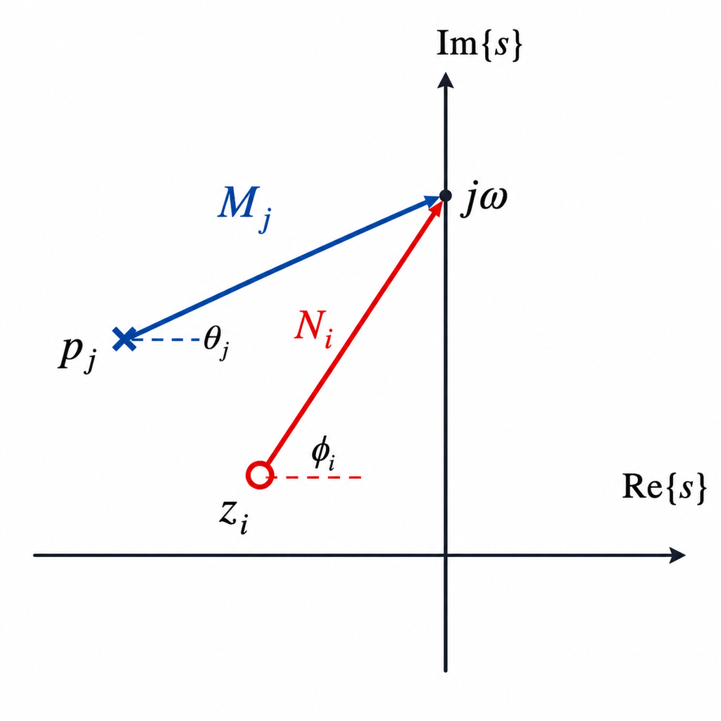

## 由零极点图对傅里叶变换几何求值

所以：

$$\begin{array}{l} H (j \omega) = k \frac {N _ {1} e ^ {j \phi_ {1}} N _ {2} e ^ {j \phi_ {2}} \cdots N _ {m} e ^ {j \phi_ {m}}}{M _ {1} e ^ {j \theta_ {1}} M _ {2} e ^ {j \theta_ {2}} \cdots M _ {n} e ^ {j \theta_ {n}}} \\ = k \frac {N _ {1} N _ {2} \cdots N _ {m}}{M _ {1} M _ {2} \cdots M _ {n}} e ^ {j [ (\phi_ {1} + \phi_ {2} + \dots + \phi_ {m}) - (\theta_ {1} + \theta_ {2} + \dots + \theta_ {n}) ]} \\ = | H (j \omega) | e ^ {j \arg H (j \omega)} \\ \end{array}$$

$$\left| H (j \omega) \right| = k \frac {N _ {1} N _ {2} \cdots N _ {m}}{M _ {1} M _ {2} \cdots M _ {n}}$$

$$\arg H (j \omega) = \left(\phi_ {1} + \phi_ {2} + \dots + \phi_ {m}\right) - \left(\theta_ {1} + \theta_ {2} + \dots + \theta_ {n}\right)$$

## 由零极点图对傅里叶变换几何求值

例：已知 $X(s)=\frac{1}{s+1/2}, Re[s]> -\frac{1}{2}$，用几何法确定傅立叶变换的幅频和相频特性。

分析：

- **极点 (Pole)**： $-1/2$， **零点 (Zero)**：无有限零点。
- **收敛域 (ROC)**：包含虚轴 ($s=j\omega$)，因此傅里叶变换存在且等于 $X(j\omega)$。

**1. 幅频特性的几何推导**：其几何意义是**极点到虚轴观测点距离的倒数**。

- **当 $\omega = 0$ 时**： 距离最短，$|\vec{V}| = 0.5$。幅值最大：$|X(j0)| = 1/0.5 = 2$。
- **当 $\omega$ 增大时**： 观测点远离实轴，矢量 $\vec{V}$ 的长度逐渐增加。
- **结论**：距离越长，幅值越小。展示了**低通滤波器**的特性。

**2. 构造几何矢量**： 从极点 $s_p = -1/2$ 指向观测点 $j\omega$ 的矢量 $\vec{V}$。$\vec{V} = j\omega - (-1/2) = \frac{1}{2} + j\omega$

**3. 相频特性的几何推导**： 由于极点在分母上，其相位贡献为负。

- **夹角**：$\angle X(j\omega) = -\theta = -\arctan(2\omega)$。
- **趋势分析**：
  - $\omega = 0 \Rightarrow \theta = 0^\circ \Rightarrow \angle X = 0^\circ$
  - $\omega \to +\infty \Rightarrow \theta \to 90^\circ \Rightarrow \angle X \to -90^\circ$
  - $\omega \to -\infty \Rightarrow \theta \to -90^\circ \Rightarrow \angle X \to +90^\circ$
1. **距离决定幅值**：极点越靠近虚轴，该频率附近的增益越高。
2. **角度决定相位**：极点在分母，贡献相位滞后；零点在分子，贡献相位超前。
3. **因此**：无需复杂运算即可快速判断系统是低通、高通还是带通等特性。

## 由零极点图对傅里叶变换几何求值

例1. 一阶系统：
$$\tau \frac{d y(t)}{dt}+y(t)= x(t)$$

$$H (s) = \frac {1 / \tau}{s + (1 / \tau)}, \quad \mathrm {R e} [ s ] > - \frac {1}{\tau}$$

$$h (t) = \frac {1}{\tau} e ^ {- \frac {t}{\tau}} u (t),$$

随着$\omega$上升， $|H(j \omega)|$单调下降，当$\omega=\frac{1}{\tau}$时,下降到最大值的$\frac { 1 } { \sqrt { 2 } }$, 最大值在$\omega=0$时取得。

相位特性， 当 $\omega=0$ 时，$\arg H(j \omega) = 0$。随着$\omega$上升，$\arg H(j \omega)$趋向$-\frac{\pi}{2}$,随着$\omega$下降，$\arg H(j \omega)$趋向$\frac{\pi}{2}$

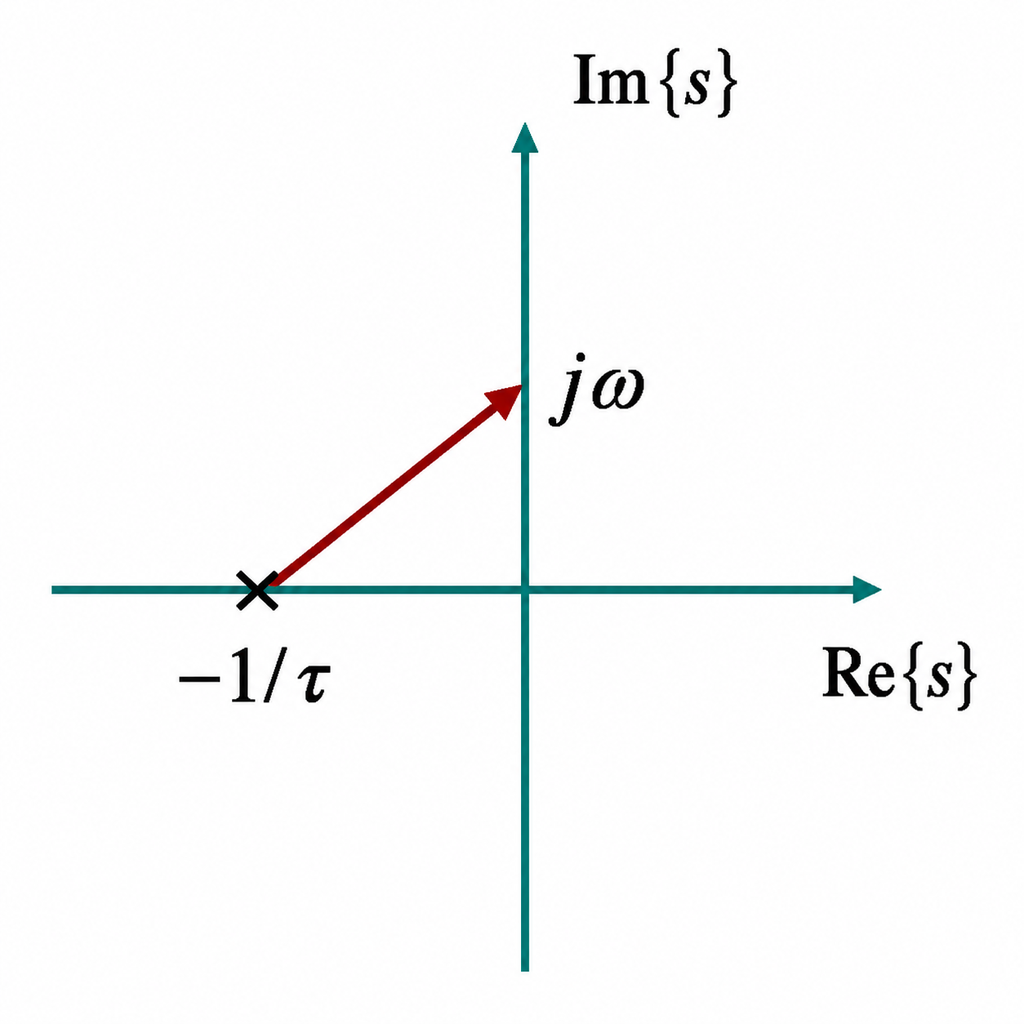

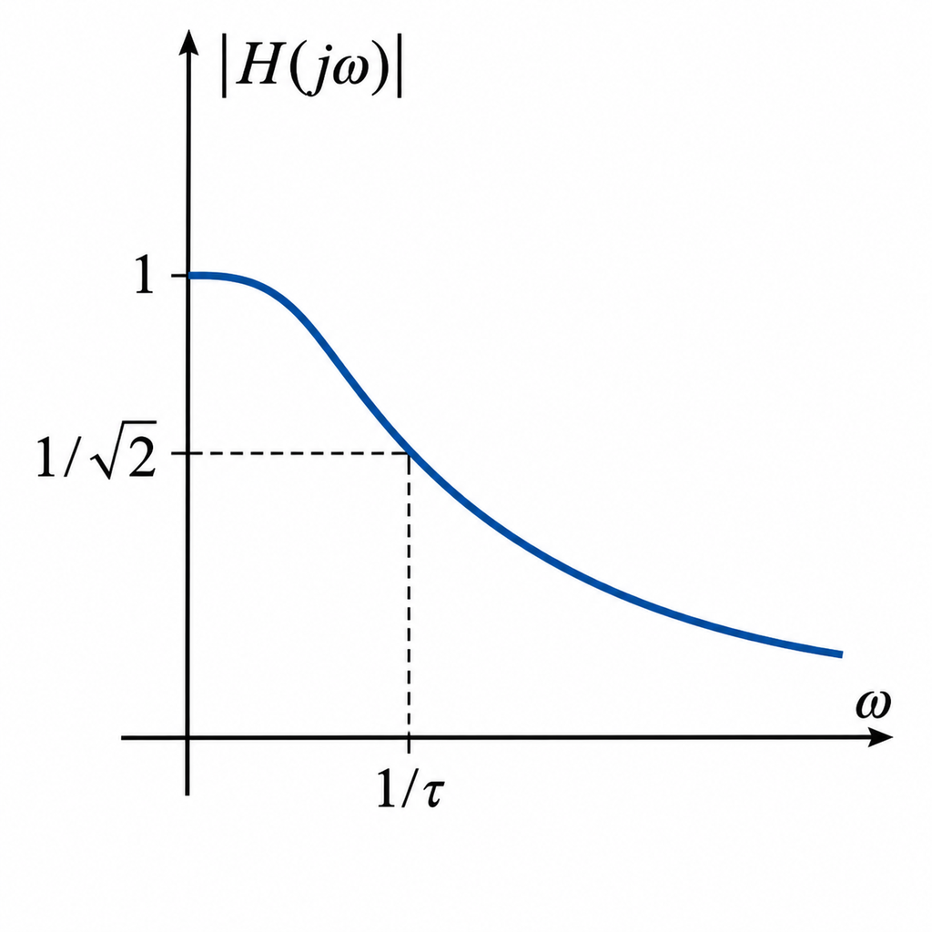

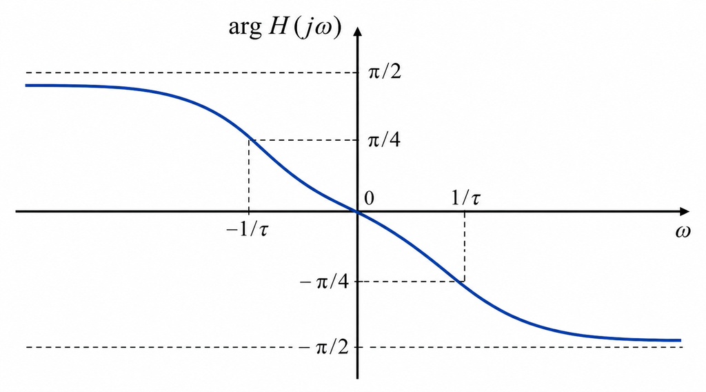